# 0. Antes de iniciar la clase …

### 0.1 Limpiar consola, entorno y fijar directorio de trabajo

Primero limpiemos la consola y la memoria activa de R.

```r
cat("\f")
```

```r
rm(list=ls())
```

Cambiemos el directorio de trabajo por la ruta a la carpeta que contiene la `Clase 15` en nuestro equipo:

```r
setwd("~/Dropbox/teaching/Taller de R/GitHub/Clases/Clase 15") # Cambiar este directorio
```

Vamos a asegurarnos que estamos sobre el directorio de trabajo correcto. Si escribimos `getwd()` sobre la consola, debemos obtener la ruta dentro de nuestro pc que hemos fijado como directorio de trabajo. Si estamos en el directorio correcto, después del ultimo `/` debemos observar el nombre la carpeta así:

- `Clase 15` (si lo descargas manualmente o creando una versión de control)
- `clase_15-master` (si lo descargas usando la función `download.file()`)

```r
getwd()
```

```
## [1] "/Users/eduardmartinez/Dropbox/teaching/Taller de R/GitHub/Clases/Clase 15"
```

De igual forma, puedes escribir sobre la consola `list.files()` para revisar los archivos que tienes en el directorio de trabajo. Deberías observar estos archivos:

```r
list.files()
```

```
## [1] "Clase 15.Rproj"      "help"                "Intro-clase-15.html"
## [4] "Intro-clase-15.Rmd"  "LICENSE"             "README.md"
## [7] "rmarkdown"           "shiny"
```

Sino observas estos archivos sobre la consola, deberías fijar el directorio correctamente antes de continuar.

### 0.2 Instalar las librerías de la clase

Vamos a verificar que todos los paquetes que vamos a usar en la clase están instalados en nuestro equipo:

```r
paquetes = c('tidyverse','data.table', 'kable', 'kableExtra','shiny')
for ( paquete in paquetes){
      if (length(grep(paquete,installed.packages()[,1])) == 0 ){ install.packages(paquete)}
      else { print(paste0('La librería ', '"', paquete ,'"', ' ya está instalada.'))}
      rm(paquete)
}
```

### 0.3 Llamar las librerías de la clase

Ahora vamos a llamar las librerías que vamos a usar en la clase:

```r
sapply(paquetes,require,character.only=T)
```

## 0.4. Clase 15

### 0.4.1. En la clase anterior vimos

- 1. Introducción a web-scraping
- 2. HTML (Hyper Text Markup Language)
- 3. Selector Gadget, xpath y css
- 4. Aplicación (atributos del elemento)
- 5. Aplicación (extraer tablas)
- 6. Aplicación (extraer datos de lluvias)
- 7. Aplicación (web drive)

### 0.4.2. Hoy veremos

- 1. RMarkdown
- 2. Shiny

## 1. Introducción a RMarkdown

### 1.1. ¿Que es R Markdown?

Markdown es un lenguaje de marcado que facilita la aplicación de formato a un texto empleando una serie de caracteres de una forma especial. En R podemos integrar este leguaje para generar informes y documentos automatizados.

### 1.2. Elementos de un archivo .Rdm

Podemos identificar tres elementos dentro de un archivo .Rdm:

- Encabezado: Esta parte del .Rdm se encuentra al inicio del documento y está contenido en los siguientes caracteres `---`. Allí se deben escribir todas las funciones que permitan asignar la configuración deseada a mi documento.
- Texto: Mientras en R el formato primario son las funciones, en R Markdown se considera el texto plano como el formato primario. Al momento de compilar R Markdown lo define como *ordinary text without R code*.
- Código: Está compuesto por todas las líneas de código que se ejecutan en la consola de R y que permiten obtener los resultados que se muestran en el *output* del .Rdm.

### 1.3. Encabezado YAML

Como mencionamos anteriormente, este va al inicio de nuestro documento y determina los parámetros generales del reporte a compilar.

```
---
title: "Introducción a R Markdown"
subtitle: "Taller de R, clase 15"
author: "Eduard Martinez"
date: "5/20/2020"
linkcolor: blue
urlcolor: blue
output: html_document
---
```

### 1.4. Hoja de referencia

Clic [aquí](https://rstudio.com/wp-content/uploads/2015/03/rmarkdown-spanish.pdf) para ir a la hoja de referencia de R Markdown.

[figure not shown]

### 1.5. Help

Vamos a la pagina de [https://rmarkdown.rstudio.com](https://rmarkdown.rstudio.com/authoring_basics.html) y revisemos las sintaxis básicas de R Markdown. En las siguientes páginas web podemos encontrar material de apoyo que nos sirve para iniciar con R Markdown.

- [Bookdown](https://bookdown.org/gboccardo/manual-ED-UCH/introduccion-al-uso-de-rmarkdown-para-la-compilacion-de-resultados-de-rstudio-en-diferentes-formatos.html)
- [r4ds](https://es.r4ds.hadley.nz/r-markdown.html)
- [Bookdown](https://bookdown.org/yihui/rmarkdown/notebook.html#using-notebooks)
- [kableExtra](https://cran.r-project.org/web/packages/kableExtra/vignettes/awesome_table_in_html.html#CellText_Specification)

### 2. Shiny

Un shiny app o una dashborad es una interfaz de usuario (UI) conectada a una seccion de R corriendo en una computadora (server)

[figure not shown]

Tomado de: http://juliawrobel.com/tutorials/shiny_tutorial_nba.html

### 2.1. Imputs de shiny

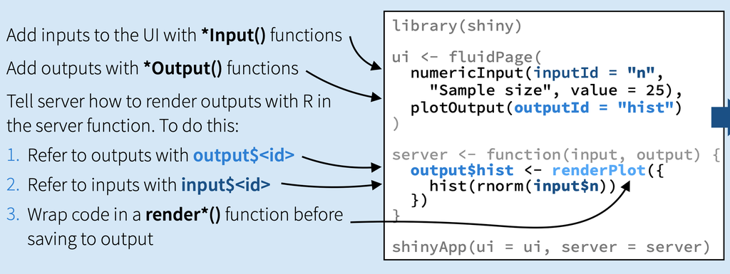

Tomado de: https://rstudio.com/wp-content/uploads/2016/01/shiny-cheatsheet.pdf

### 2.2. Help

Veamos algunos ejemplos de shiny: https://github.com/rstudio/shiny-examples

```
library(shiny)
runExample(example = "04_mpg")
```

Otras galeriias: https://shiny.rstudio.com/gallery/

### 2.3. Alojar la app en el servidor de shiny

1. Ir a https://www.shinyapps.io

[figure not shown]

2. Crean un usuario y una contraseña (preferiblemente usen el correo de su cuenta de GitHub)

[figure not shown]

3. Generen un dominio para su cuenta (yo uso eduard-martinez, el nombre de mi usuario en GitHub)

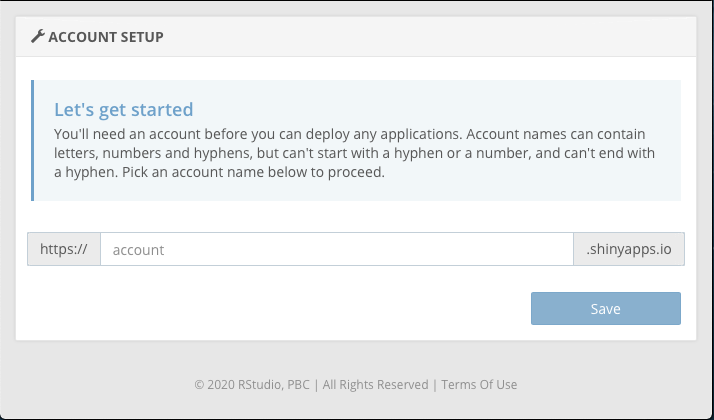

4. Obtener un tocken

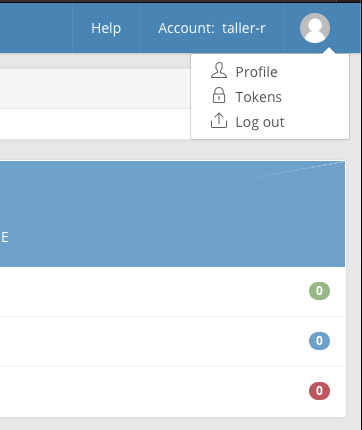